# Variable Selection Question 2

### Multicolinearity

Let’s ignore the previous kelp size / abundance for now.

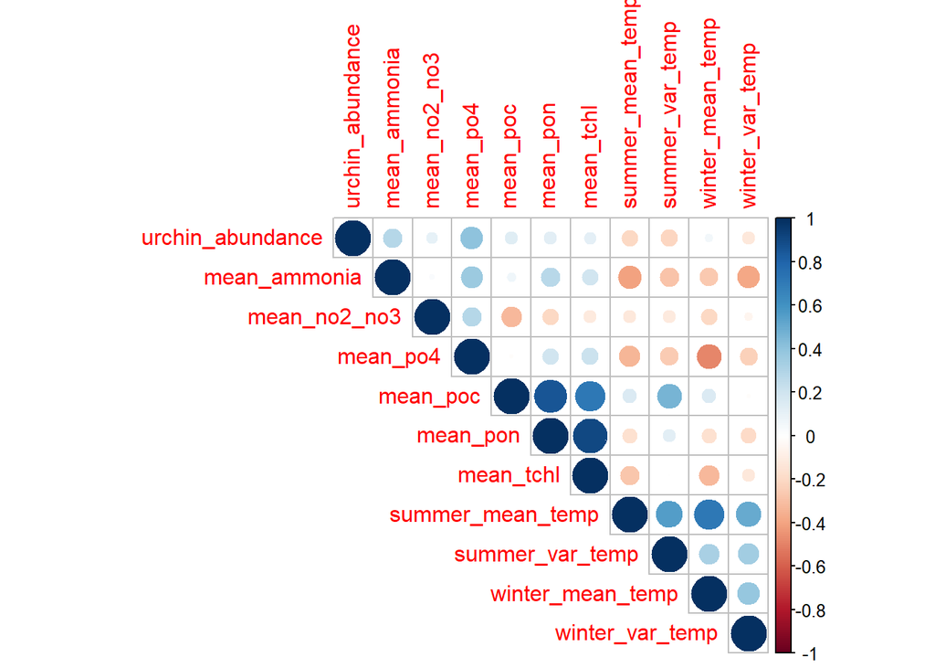

```r
lmdat <- lmdat %>%
  dplyr::select(-winter_mean_temp,-winter_var_temp)
```

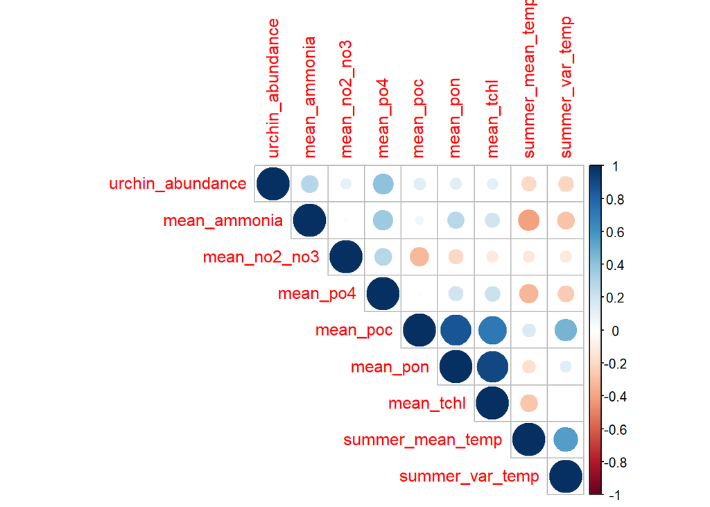

Particulate organic carbon (`poc`) is highly correlated with particulate organic nitrogen and mean total chlorophyll. I’ll remove particulate organic carbon.

```r
lmdat <- lmdat %>%
  dplyr::select(-mean_poc)
```

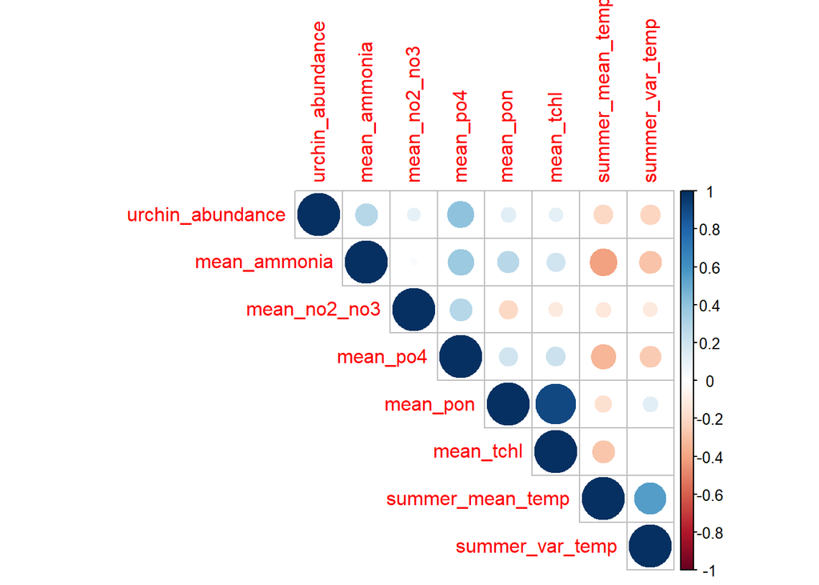

I think that for the remaining correlations, I’ll see what happens in stepwise model selection. These are the final variables:

```
##  [1] "year"              "month"             "site"
##  [4] "mapy_mean_density" "mapy_mean_count"   "mapy_mean_fronds"
##  [7] "mapy_max_fronds"   "mapy_mean_hld"     "mapy_max_hld"
## [10] "urchin_abundance"  "mean_ammonia"      "mean_no2_no3"
## [13] "mean_po4"          "mean_pon"          "mean_tchl"
## [16] "summer_mean_temp"  "summer_var_temp"   "prev_mean_density"
## [19] "prev_mean_count"   "prev_mean_fronds"  "prev_max_fronds"
## [22] "prev_mean_hld"     "prev_max_hld"      "urchin_presence"
```

### Transform variables

According to the script [04_explore_predictors](https://github.com/mfisher5/504_BiodivSB/tree/master/scripts), many of the predictor variables are not normally distributed.

```r
lmdat.t <- lmdat %>%
  mutate(summer_var_temp = log(summer_var_temp),
         mean_pon= log(mean_pon),
         mean_tchl= log(mean_tchl))
```

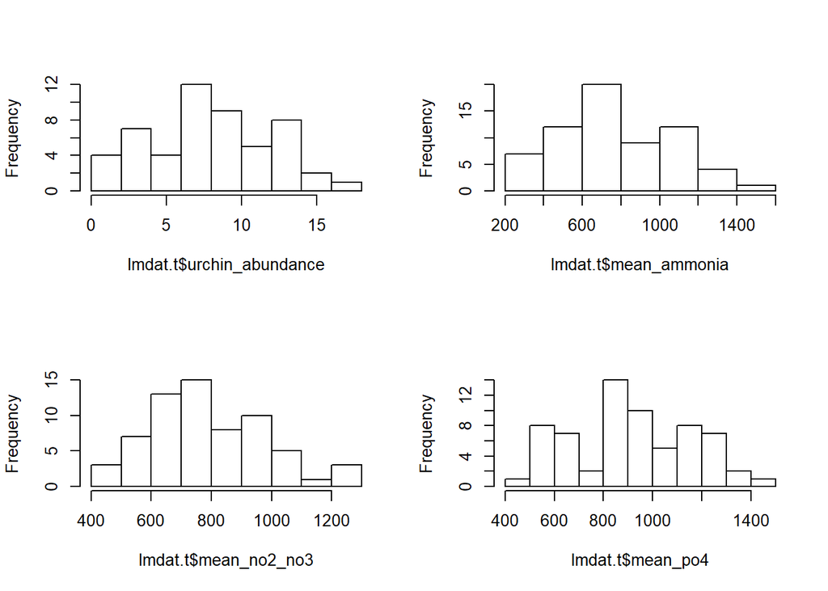

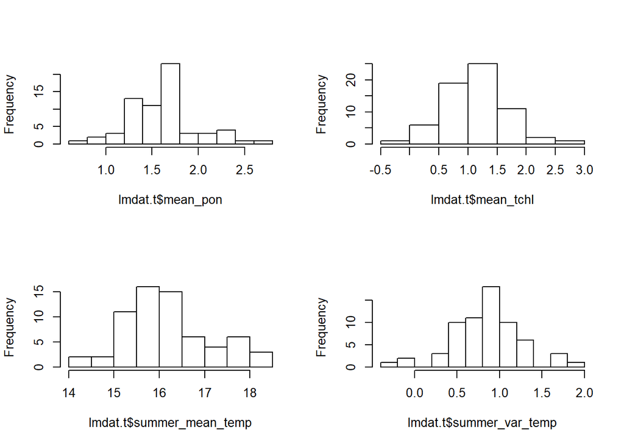

## Response Variables

Mean holdfast density is normal.

—